# Prediction of the Weight Lifting Exercises Quality

Yuko Torii

August 30, 2016

## Overview

The purpose of this project is to predict the quality of weight lifting exercises. The quality is categorized into 5 classes. The Class A means that the way of the exercise is correct, and the Class B, C, D and E mean that each exercise includes specified common mistakes in a different way. The original data of this project is the Weight Lifting Exercises Dataset (see Velloso et al. 2013). In order to predict the quality, I used the R machine learning packages such as `caret`, `rpart`, `randomForest` and `gbm`.

## Data Processing

We can download and read the training data `pml-training.csv` and the test data `pml-testing.csv` with the following code:

```r
if (!file.exists("pml-training.csv")) {
    download.file(
        "https://d396qusza40orc.cloudfront.net/predmachlearn/pml-training.csv",
        destfile="pml-training.csv")
}

if (!file.exists("pml-testing.csv")) {
    download.file(
    "https://d396qusza40orc.cloudfront.net/predmachlearn/pml-testing.csv",
    destfile="pml-testing.csv")
}

pml_training <- read.csv("./pml-training.csv")
pml_testing <- read.csv("./pml-testing.csv")
```

The numbers of rows and columns of the training data are:

```r
dim(pml_training)
```

```
## [1] 19622   160
```

According to the paper “Qualitative Activity Recognition of Weight Lifting Exercises” (Velloso et al. 2013), there are 96 derived feature sets,

- 4 sensors(belt, arm, dumbbell and forearm) * 3 Euler angles(roll, pitch and yaw) * 8 features(mean, variance, etc.) = 96 derived features

however, I tried the following code

```r
str(pml_testing)
```

and found out that our test data is missing all of them, i.e. the derived features are all NA values, therefore we have to predict without them.

```r
pml_testing2 <- pml_testing[,-160]      # exclude the problem_id
pml_testing2 <- pml_testing2[,-(3:7)]   # exclude timestamps and windows
pml_testing2 <- pml_testing2[,-1]       # exclude the row number
pml_testing2 <- pml_testing2[colSums(!is.na(pml_testing2)) > 0] # non-NA only
titles <- c(colnames(pml_testing2), "classe")
pml_training2 <- pml_training[,titles]
dim(pml_training2)
```

```
## [1] 19622    54
```

The number of the remaining features is 54 including the `classe` that we will predict.

As the test data `pml-testing.csv` is used for the Project Prediction Quiz, I randomly split the training data into `training` (60%) and `testing` (40%).

```r
library(caret)
set.seed(20168)
trainIndex = createDataPartition(pml_training2$classe,p=0.6,list=FALSE)
training = pml_training2[trainIndex,]
testing = pml_training2[-trainIndex,]
```

The training data set `training` is used for training models and the test data set `testing` is be used for performance evaluation.

## Exploratory Data Analysis

Let’s perform the **principal component analysis** on the training data set to reduce predictors and create a scatter plot of PC1(the x-axis) and PC2(the y-axis)(see **Figure 1**).

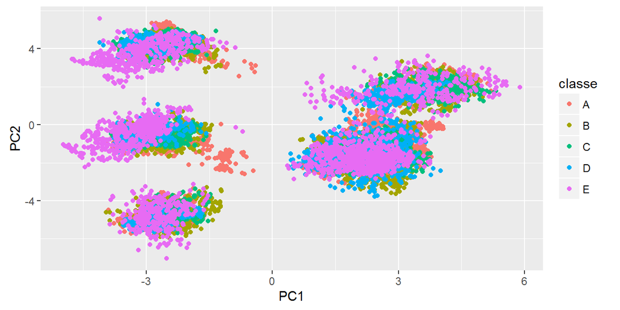

Figure 1: The Scatter Plot of the Weight Lifting Exercises Dataset

```r
preProc <- preProcess(training[,-54],method="pca",pcaComp=2)
trainPC <- predict(preProc,training[,-54])
trainPC <- data.frame(trainPC, classe=training$classe)

library(ggplot2)
qplot(PC1, PC2, colour=classe, data=trainPC)
```

Each cluster in the plot seems to represent a participant. As classes are not easily distinguishable, algorithms such as the k-nearest neighbors algorithm do not seem to be suitable for solving this problem.

## Training and Evaluating a Model

### Decision Tree

Let’s create a model using the **decision tree** algorithm and predict the classification.

```r
modTree <- train(classe ~ ., method="rpart", data=training)
predTree <- predict(modTree, newdata=testing)
matrixTree <- confusionMatrix(predTree, testing$classe)
matrixTree$table
```

```
##           Reference
## Prediction    A    B    C    D    E
##          A 2035  615  627  573  212
##          B   34  509   48  223  191
##          C  158  394  693  490  389
##          D    0    0    0    0    0
##          E    5    0    0    0  650
```

```r
matrixTree$overall['Accuracy']
```

```
##  Accuracy
## 0.4954117
```

The generated tree is shown in **Figure 2**.

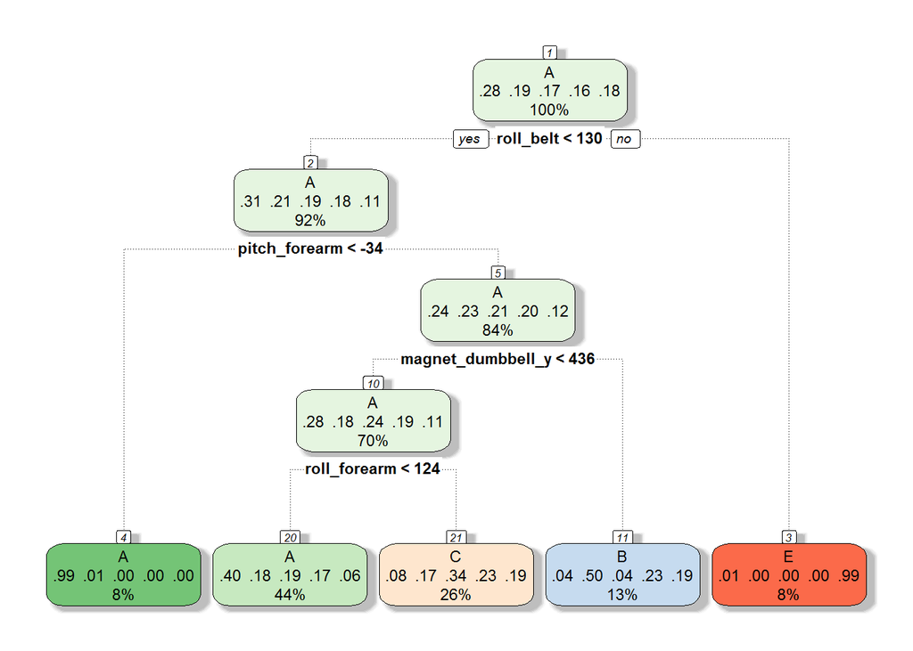

Figure 2: The Decision Tree for the Weight Lifting Exercises Prediction

```r
library(rattle)
fancyRpartPlot(modTree$finalModel, sub="")
```

The decision tree works fine, but the accuracy is quite low (0.4954117). One of the reason of this is that the tree does not grow enough to classify the Class D.

## Improving Model Performance

We can improve decision trees by

- tuning control options
- using different tree algorithms,

however, I used ensemble meta-algorithms **random forests** and **boosting** here as they are time-consuming but tend to give better results by combining multiple models.

### Random Forests and Boosting

Here is the code to perform random forests and boosting. I used Greski (2016) as a reference to implement parallel processing.

```r
## Configure parallel processing
library(parallel)
library(doParallel)
cluster <- makeCluster(detectCores() - 1)   # convention to leave 1 core for OS
registerDoParallel(cluster)

## Configure trainControl object
fitControl <- trainControl(method = "cv", number = 10, allowParallel = TRUE)

## Develop training model
# Random Forests
modRf <- train(classe~ ., data=training, method="rf", prox=TRUE,
               trControl=fitControl)
predRf <- predict(modRf, newdata=testing)

# Boosting with trees
modGbm <- train(classe ~ ., method="gbm", data=training, verbose=FALSE,
                trControl=fitControl)
predGbm <- predict(modGbm, newdata=testing)

## De-register parallel processing cluster
stopCluster(cluster)
```

The results of evaluation with random forests are as follows:

```r
matrixRf <- confusionMatrix(predRf, testing$classe)
matrixRf$table
```

```
##           Reference
## Prediction    A    B    C    D    E
##          A 2230   17    0    0    0
##          B    1 1492    8    0    1
##          C    0    7 1350   14    2
##          D    0    0   10 1271    4
##          E    1    2    0    1 1435
```

```r
matrixRf$overall['Accuracy']
```

```
##  Accuracy
## 0.9913332
```

The results of evaluation with boosting with trees are as follows:

```r
matrixGbm <- confusionMatrix(predGbm, testing$classe)
matrixGbm$table
```

```
##           Reference
## Prediction    A    B    C    D    E
##          A 2204   50    0    0    3
##          B   18 1416   48    5   23
##          C    6   47 1293   40   12
##          D    3    2   26 1231   24
##          E    1    3    1   10 1380
```

```r
matrixGbm$overall['Accuracy']
```

```
## Accuracy
##  0.95896
```

The accuracy of random forests are higher than that of boosting.

## Conclusions

Here false positives mean that the Class B, C, D and E are incorrectly identified as the Class A, i.e. ineffective exercises are wrongly misclassified as effective exercises.

The expected out of sample error will be a little worse than in sample error because machine learning algorithms such as random forests tend to overfit.

## References

Greski, Leonard. 2016. “Improving Performance of Random Forest in Caret:train().” GitHub. https://github.com/lgreski/datasciencectacontent/blob/master/markdown/pml-randomForestPerformance.md.

Velloso, E., A. Bulling, H. Gellersen, W. Ugulino, and H. Fuks. 2013. “Qualitative Activity Recognition of Weight Lifting Exercises. Proceedings of 4th International Conference in Cooperation with SIGCHI (Augmented Human ’13).” ACM SIGCHI. http://groupware.les.inf.puc-rio.br/har.